# Introduction

Marie-Pierre Etienne

marie-pierre.etienne@ensai.fr

ENSAI - CREST

https://marieetienne.github.io/statspat

2026-11-23

## Cadre

La statistique spatiale est une branche de la statistique qui se concentre sur l’analyse et la modélisation de données localisées géographiquement ou spatialement.

Elle **prend en compte la localisation des observations et les relations spatiales** entre elles, notamment elle permet de lier la dépendance et la localisation spatiale.

### Pour quelles applications ?

- Sciences de la terre : position des séismes.
- Environnement : température, pluie
- Epdémiologie : nombre de cander par régions administratives
- Ecologie : localisation des différents arbre d’une espeèce au sein d’une parcelle,
- Agrnomie : répartition des pucerons dans une parcelle cultivée
- Economie spatiale : taux de chomage par région administrative, prix au m2 des appartements au sein d’une ville
- Imagerie : Couleur d’un pixel en fonction de sa localisation sur l’image

# Trois types de données spatiales

## 1. Données géostatistiques

### Description

- **Observation** : A un point $s$ d’un domaine spatial $D$, on associe une valeur observée $Z(s)$. La grandeur mesurée est définie partout mais on l’observe seulement en $n$ points $s_1, \ldots, s_n$.
- **Caractéristiques** :
  - Positions continues.
  - Généralement irrégulièrement espacées.
  - Modèles courants : modèles de champs spatiaux
- **Exemples** : Porosité du sol, concentrations de polluants.Températures mesurées à des stations météo,

### Visualisation

- Carte avec des points représentant les positions des observations.

### Objectifs

- Modélisation.
- Séparation des variations à différentes échelles.
- Prédiction (krigeage).

## 1. Exemple de données géostatistiques

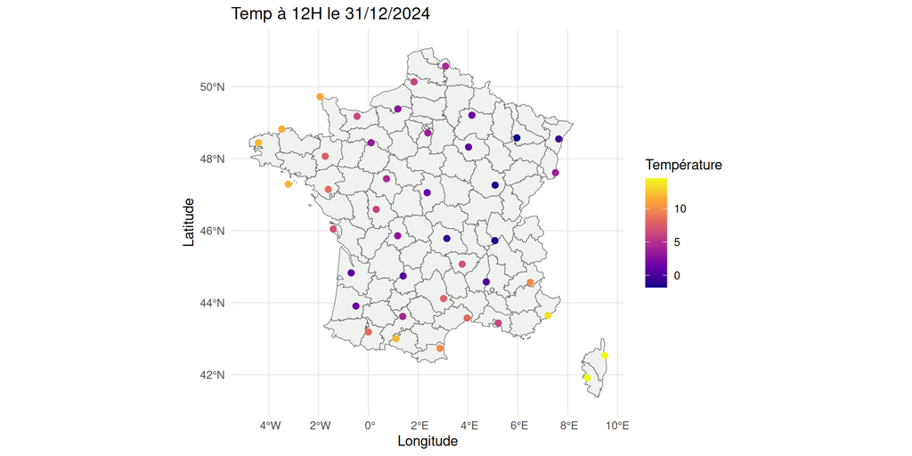

## 2. Données en réseau ou maillage fixe (données lattice)

- **Observation** : pour un réseau donné, on associe à chaque maille $i$ du réseau une valeur $Z_i$. La grandeur mesurée est définie pour l’ensemble de la maille, elle ne varie pas continuement. Les données sont donc agrégées sur des zones géographiques définies (polygones).
- **Exemples** :
  - Pourcentage de groupe sanguin par région.
  - Prix au m2 par arrondissement à Paris.
  - Pixels dans une image.

### Visualisation

- Cartes choroplèthes.

### Objectifs

- Explicatifs (lien avec des covariables)
- Analyse des corrélations spatiales.
- Restauration d’images.

## 2. Exemple de données lattice

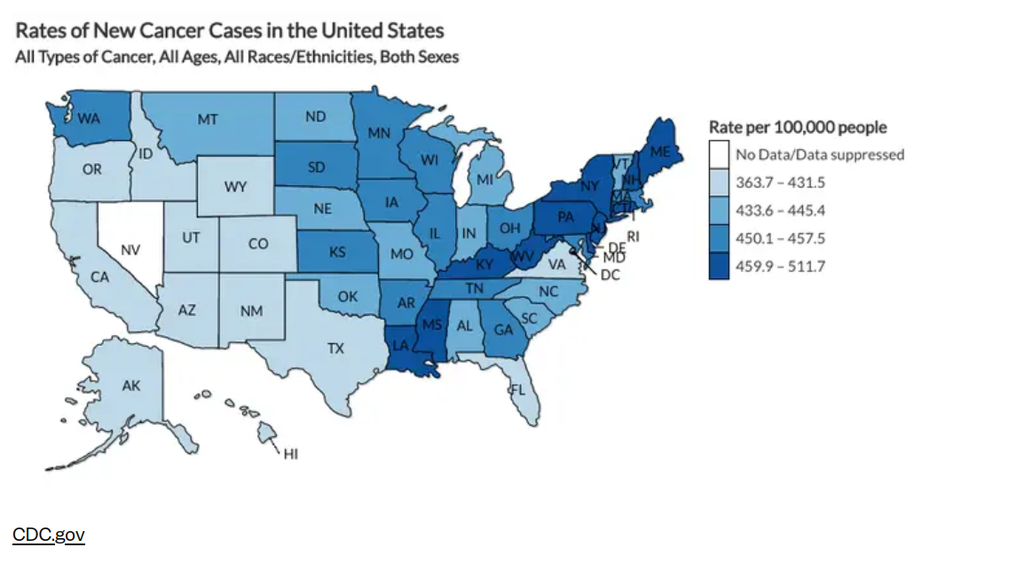

Figure 1

## 3. Données ponctuelles

- **Observations** on note la présence d’un évènement en la position $s$. $s_i$ est donc la position du ième évènement d’intérêt
- Exemples : Positions des chênes dans une forêt, position des épicentres de séismes

### Visualisation

- Carte de points.

### Objectifs

- Régularité.
- Distribution aléatoire (Poisson).
- Agrégation.

## 3. Exemple de données ponctuelles

Figure extraite de Renner et al. (2015)

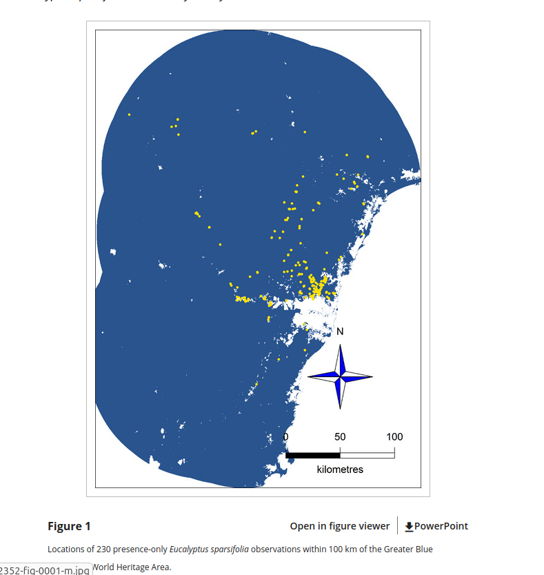

Figure 2

## Exercice

- Sciences de la terre : position des séismes.
- Environnement : température, pluie
- Epdémiologie : nombre de cander par régions administratives
- Ecologie : localisation des différents arbre d’une espeèce au sein d’une parcelle,
- Agrnomie : répartition des pucerons dans une parcelle cultivée
- Economie spatiale : taux de chomage par région administrative, prix au m2 des appartements au sein d’une ville
- Sociologie : Localisation des crimes, des stations de service.
- Imagerie : Couleur d’un pixel en fonction de sa localisation sur l’image

## Cadre du cours

La statistique spatiale analyse des données localisées dans l’espace.

Ces données se classent en trois grandes catégories, nous étudierons les deux premières dans ce cours.

- **Champs spatiaux observés en quelques positions**
- **Valeurs associées à des régions** (données lattice)
- **Événements géolocalisés** (processus ponctuels)

## References

Renner, Ian W, Jane Elith, Adrian Baddeley, et al. 2015. “Point Process Models for Presence-Only Analysis.” *Methods in Ecology and Evolution* 6 (4): 366–79.